# Spatial Analysis Inference

Evgeny Noi

August 30, 2021

# Types of Operations on Spatial Data

## Common Table and Attribute Tasks

> Attributes are accessed through the Attribute table in ArcGIS Pro.
- Creating tables
- Creating a layer from a table of coordinates (XY table to point)
- Import, copy and convert (e.g. [Excel to Table](https://pro.arcgis.com/en/pro-app/latest/tool-reference/conversion/excel-to-table.htm))
- Adding and modifying fields (e.g. [Fields Toolset](https://pro.arcgis.com/en/pro-app/latest/tool-reference/data-management/an-overview-of-the-fields-toolset.htm))
- Displaying tables (e.g. Filtering - see next slide)

## Filtering

- **Filtering**. One can use Query Builder to write a query interactively or in SQL editor.

Interactive Mode:

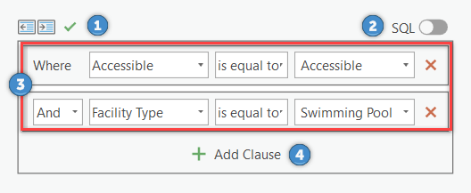

SQL Mode:

You can find more informaiton on how to use SQL in ArcGIS in the [ArcGIS Pro Documents](https://pro.arcgis.com/en/pro-app/latest/help/mapping/navigation/sql-reference-for-elements-used-in-query-expressions.htm)

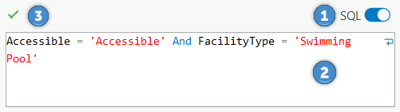

## Common table and attribute tasks

- Interactive with selected subset (e.g. **[Zoom to highlighted](https://pro.arcgis.com/en/pro-app/latest/help/data/tables/highlight-records-within-a-selection-set.htm)**)
- Editing attribute values (e.g. you lab C)
- Calculating new fields (see [docs](https://pro.arcgis.com/en/pro-app/latest/tool-reference/data-management/calculate-field.htm))
- Associations among tables (joining, relating, using relationship classes)
  - Pay attention to [spatial joins](https://pro.arcgis.com/en/pro-app/latest/help/data/tables/spatial-joins-by-feature-type.htm)
- Geocoding
- Exporting

## How Spatial Join Works

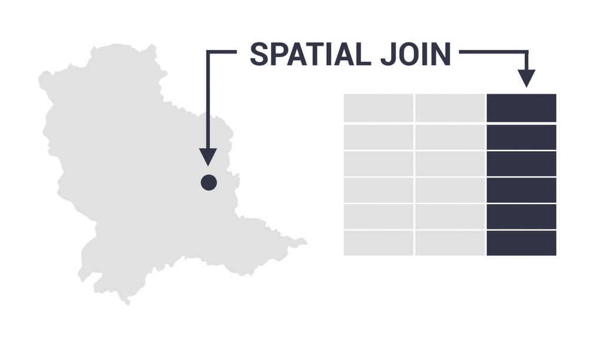

## Common Spatial Join Types

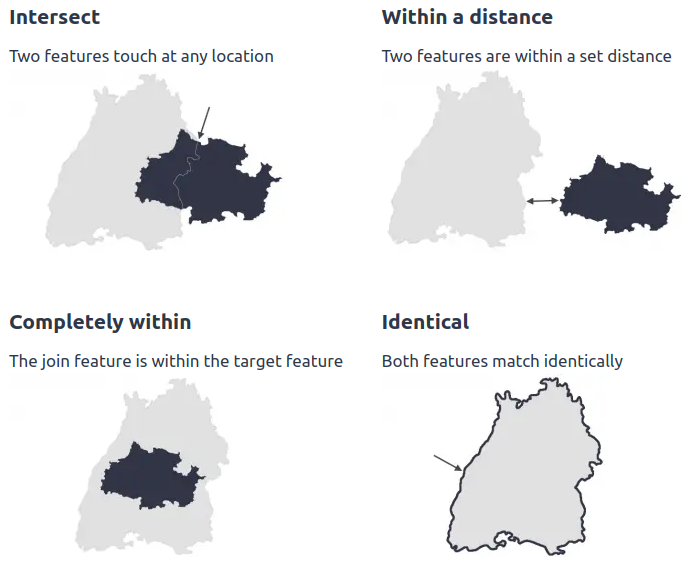

## Join Relations

- One-to-one join (one point inside a polygon)
- One-to-many join (three points inside a polygon)

Read more on Spatial Joins in ArcGIS Pro in the [docs](https://pro.arcgis.com/en/pro-app/latest/help/data/tables/spatial-joins-by-feature-type.htm)

# Common Operations on Geometry

## Extract Toolset

- Clip
- Select
- Split
- Table select

## Clipping

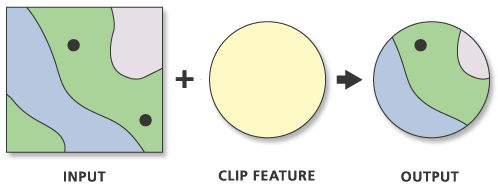

## Example from previous lecture: Clipping US cities to the North Carolina

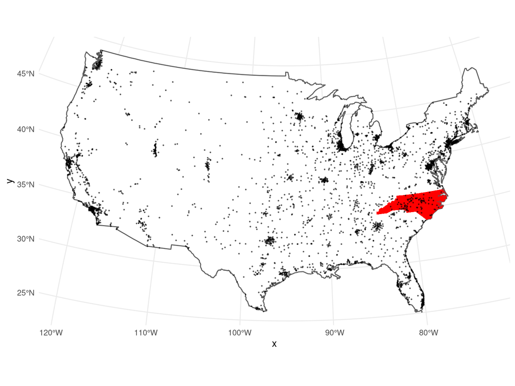

## Splitting

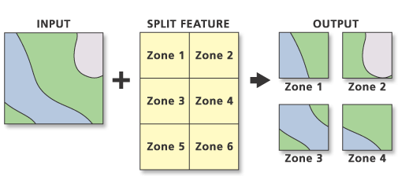

## Overlay Toolset [docs](https://pro.arcgis.com/en/pro-app/latest/tool-reference/analysis/an-overview-of-the-overlay-toolset.htm)

- Count overlapping features
- Erase
- Identity
- Intersect
- Union
- Update

## Identity

> Computes a geometric intersection of the input features and identity features. The input features or portions thereof that overlap identity features will get the attributes of those identity features.

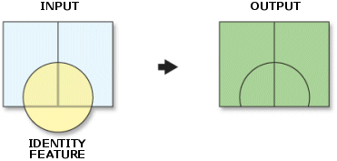

## Intersect

> Computes a geometric intersection of the input features. Features or portions of features that overlap in all layers or feature classes will be written to the output feature class.

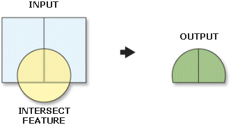

## Union

> Computes a geometric union of the input features. All features and their attributes will be written to the output feature class.

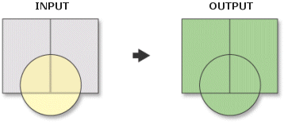

## Update

> Computes the geometric intersection of the Input Features and Update Features. The attributes and geometry of the input features are updated by the update features in the output feature class.

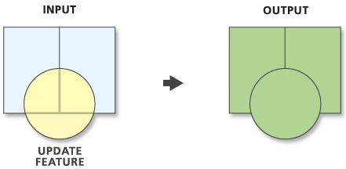

## Proximity Toolset [docs](https://pro.arcgis.com/en/pro-app/latest/tool-reference/analysis/an-overview-of-the-proximity-toolset.htm)

- Buffer
- Multiple Ring Buffer
- Tessalation (Thiessen Polygons)
- Polygon Neighbors

## Buffer

> Creates a polygon at a set distance surrounding the features.

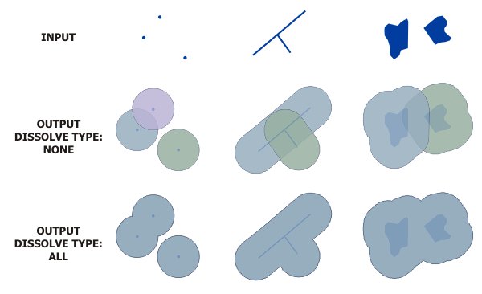

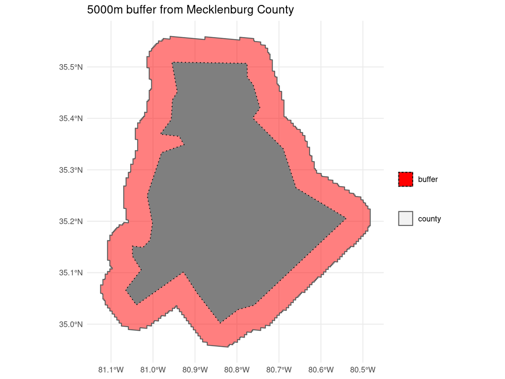

## Thiessen (Voronoi) Polygons

> Any location within a Thiessen polygon is closer to its associated point than to any other point input feature.

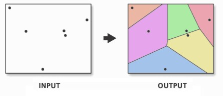

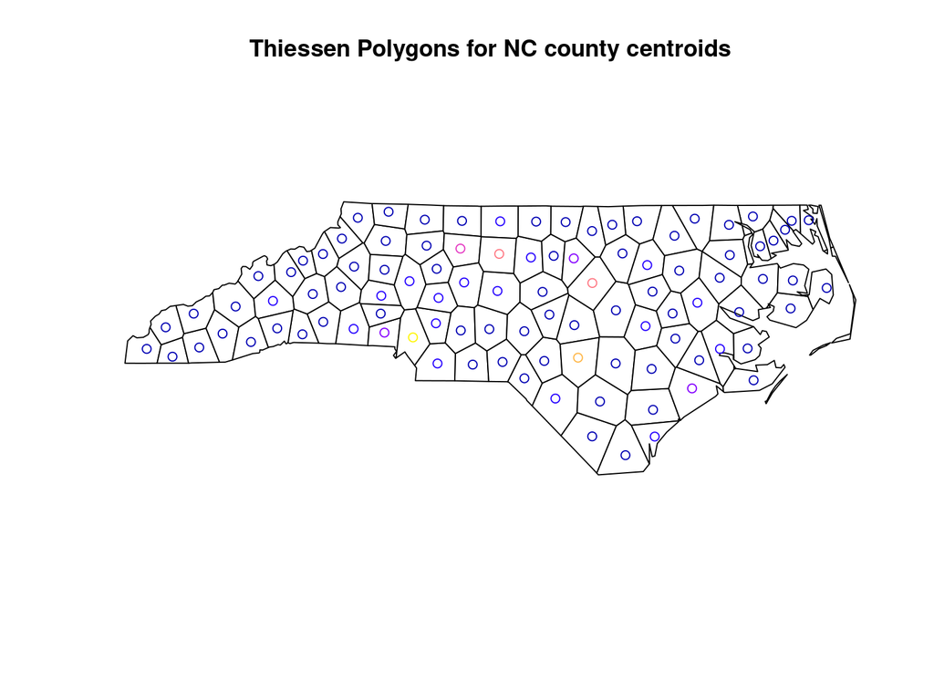

## Statistics Toolset [docs](https://pro.arcgis.com/en/pro-app/latest/tool-reference/analysis/an-overview-of-the-statistics-toolset.htm)

- Enrich
- Frequency
- Summarize Nearby
- Summarize Within
- Summary Statistics
- Tabulate Intersection

## Enrich

> Enriches data by adding demographic and landscape facts about the people and places that surround or are inside data locations. The output is a duplicate of your input with additional attribute fields. This tool requires an ArcGIS Online organizational account or a locally installed Business Analyst dataset.

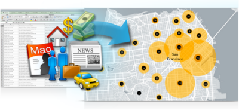

## Frequency

> Reads a table and a set of fields and creates a new table containing unique field values and the number of occurrences of each unique field value.

## Summarize Nearby (~Within)

> Finds features that are within a specified distance of features in the input layer and calculates statistics for the nearby features. Distance can be measured as a straight-line distance, a drive-time distance (for example, within 10 minutes), or a drive distance (within 5 kilometers). Drive-time and drive distance measurements require that you are logged in to an ArcGIS Online organizational account with Network Analysis privileges, and they consume credits.

## Example scenarios using Summarize Nearby:

- Calculate the total population within 5 minutes of driving time of a proposed new store location.
- Calculate the number of freeway access ramps within a 1-mile driving distance of a proposed new store location to use as a measure of store accessibility.

## Summary Statistics:

- Sum
- Mean
- Minimum
- Maximum
- Range
- Standard Deviation
- Count
- First
- Last
- Median
- Variance
- Unique

## Tabulate Intersection

> Computes the intersection between two feature classes and cross-tabulates the area, length, or count of the intersecting features.

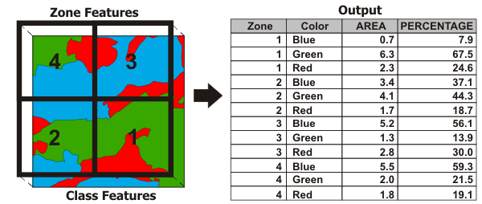

# More Examples on Spatial Analysis

## Spatial Analysis of Rail Access in North Carolina

- Download the data from [here](https://drive.google.com/file/d/1-jQaosWdtC4rAAnOuZsrn0Ioq_yzxkQ-/view?usp=sharing) and answer the following questions:
  - How many segments are there in the rail data layer?
  - How many counties does the rail intersects with?
  - What is the total (combined) population of these counties?
  - How many cities are located within 1 mile from the railroad?
  - What is the combined population of those cities?

## Spatial Analysis (continued)

- How many hospitals are located within 1 mile from the railroad?
- Calculate the number of cites per county, create a choropleth map.
- Calculate the number of hospitals per county, create graduated symbols map.

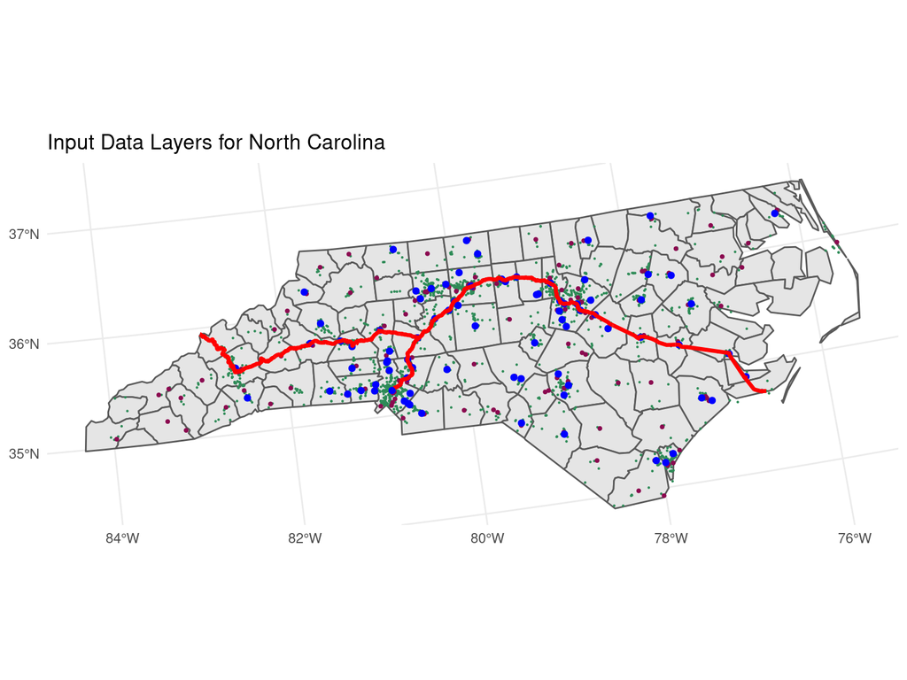

# Questions?

[figure not shown]